# Acessing Census Data in R

Author

Mark Nepf (mnepf@uw.edu)

Published

October 1, 2026

## Introduction

The following vignette provides a guide for accessing [United States Census Bureau](https://www.census.gov/) data directly through R. The primary R package for doing so is `tidycensus`, developed by [Walker & Herman (2024)](https://walker-data.com/tidycensus/).

`tidycensus` allows users to quickly download and work with Census data entirely within R. Data are automatically formatted into dataframes, making them compatible with popular data science packages like `tidyverse`. Additionally, users can request spatial data (e.g., Census tract boundaries) all through the same code, making these data compatible with packages like `sf` that allow for spatial mapping and analysis.

### R Packages

You will need the following R packages. If you have already installed them, skip the `install.packages` lines.

```r
# install
install.packages("tidycensus")  # accessing Census data
install.packages("tidyverse")  # cleaning data
install.packages("janitor")  # cleaning data
install.packages("gt")  # creating tables
```

```r
# load
library(tidycensus)
library(tidyverse)
library(janitor)
library(gt)
```

### Census Application Programming Interface

`tidycensus` accesses Census data through the Census Bureau’s Application Programming Interface (API). An API is a way for one computer program to request data from another program. In this case, R sends a request to the Census Bureau and receives the requested data directly. To make these requests, however, you will need a **Census API Key**. API keys are free and help the Census Bureau monitor and manage API usage.

You can request a free API key from the Census Bureau [here](https://api.census.gov/data/key_signup.html). This link will bring you to the following page:

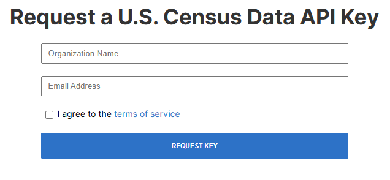

Figure 1: Census API Key Request Page

You will be asked to provide an *Organization Name* and *Email Address*. The former can be your place of work or academic institution, or simply your name or “Individual” or “Personal.” Once entered, click `REQUEST KEY` and the Census Bureau will email you your API key (~5 minutes). The key will be a long alphanumeric string (~40 characters). Don’t worry, you only need to install it once!

To install you API key, use the `census_api_key` function (part of the `tidycensus` package).

```r
# install Census API key
census_api_key(key = "YOUR_KEY_HERE", install = TRUE)
```

Replace `"YOUR_KEY_HERE"` with the key provided in the email. By setting `install = TRUE`, you are telling R to save your key to your local R environment. This prevents you from needing to enter the key each time you use `tidycensus`.

**TIP**

If running `census_api_key` returns **Error: A CENSUS_API_KEY already exists**, it means you already have an API key installed. You can proceed without re-installing, or you can overwrite the existing key by adding `overwrite = TRUE` to the `census_api_key` function.

```r
# overwrite Census API key
census_api_key(key = "YOUR_KEY_HERE",
               install = TRUE,
               overwrite = TRUE)
```

After installing the key, restart R (or restart your R session). Once R is reloaded, you can check whether your API key was installed by running `Sys.getenv("CENSUS_API_KEY")`, which will print your API key in the R Console.

```r
Sys.getenv("CENSUS_API_KEY")
```

**NOTE**

The output from `Sys.getenv("CENSUS_API_KEY")` is not shown in this vignette, as API keys should not be shared.

It is good practice to keep your API key hidden and not include it in files that you plan to publish or distribute. In other words, treat your Census API key like a password. By running `census_api_key` once, you store your key in your local R environment, allowing `tidycensus` to use it without exposing the key in your code.

Once your API key is installed, you can run `tidycensus` functions normally, without specifying an API key each time. `tidycensus` will find your API key within your local R environment when functions like `load_variables`, `get_acs`, and `get_decennial` are used.

## Finding Variables

The first part of working with Census data is identifying the variable(s) you want. The Census Bureau organizes data into tables based on broad concepts. Each table then contains several variables that represent different subsets of that concept.

For example, a table may contain the concept of *Total Population*, while nested variables within that table provide estimates for the total population at different age brackets (e.g., under 5, 5 to 9, and so forth).

To explore what data are available, run the `load_variables` function. This function works equivalently for both Decennial Census data and American Community Survey (ACS) data, returning a searchable dataframe with the variables available for that particular Census dataset and year.

```r
# Decennial Census

decennial_pl_vars <- load_variables(year = 2020, dataset = "pl")  # 2020 Redistricting Data

decennial_dhc_vars <- load_variables(year = 2020, dataset = "dhc")  # 2020 Demographic & Housing Characteristics

decennial_dp_vars <- load_variables(year = 2020, dataset = "dp")  # 2020 Demographic Profile


# American Community Survey

acs1_2022_vars <- load_variables(year = 2022, dataset = "acs1")  # 2022 ACS 1-year

acs5_2022_vars <- load_variables(year = 2022, dataset = "acs5")  # 2022 ACS 5-year
```

You can then open and inspect these dataframes by running `View` (as below), or by double-clicking on the object in the Data Environment.

```r
View(decennial_pl_vars)

View(acs1_2022_vars)
```

**TIP**

Once opened, you can search for variables that relate to your topic of interest. Rather than scrolling through thousands of variables, use the search bar in the top right to look for specific terms. For instance, searching for “population” will temporarily filter the dataframe to variables dealing with population estimates.

Included in these dataframes are the `name`, `concept`, and `label` associated with each variable.

- `name`: internal ID used by the Census Bureau to uniquely identify each variable
- `concept`: broader measurement concept (i.e., table) to which the variable belongs
- `label`: description of the specific variable (i.e., the variable nested within `concept`)

**CAUTION**

Census variable names and availability can change across years and datasets. A variable that exists in one year may not exist in another. When working with multiple years, it is a good idea to check the available variables for each year before downloading the data.

**click here for information on choosing the right Census dataset**

Choosing a Census dataset is not simply a technical decision. Before downloading data, you should think critically about what you are trying to measure and what type of data are appropriate for your research question.

Census products vary in their:

- Time Period: when the data were collected or what years they represent
- Geographic Coverage: which geographic units are available
- Geographic Scale: from national and state-level data to counties, tracts, and block groups
- Population/Topic: what concepts and variables are included
- Estimation Method: a complete enumeration versus a survey estimate
- Uncertainty Level: whether estimates include margins of error
- Data Availability: whether the same variable or geography is available consistently over time

For example, when working with ACS data, the choice between the 1-year and 5-year estimates depends on both the geographic area you need and the type of analysis you are conducting. ACS 1-year estimates provide more recent information for larger geographic areas (e.g., counties), while ACS 5-year estimates are often more precise and available for smaller geographic areas (e.g., Census tracts and block groups).

**TIP**

The important thing to keep in mind is that there is no single Census dataset that is always the “best” choice. Your research question should determine which Census product, year, geography, and variables you use.

Before making a request with `tidycensus`, ask yourself:

- What population or concept am I trying to measure?
- What geographic area do I need?
- What time period do I need?
- Which Census product provides the appropriate data?
- Are the variables I need available for that product, geography, and year?
- What limitations or uncertainty should I consider when interpreting the data?

Thinking through these questions before downloading data can prevent common problems such as using the wrong dataset, selecting an inappropriate geographic scale, comparing estimates that are not directly comparable, or assuming that a variable is available for every year.

See Census Information for more.

## Downloading

Once you know which variables you want, `tidycensus` provides several functions for downloading data. Two of the most commonly used are `get_decennial` (Decennial Census) and `get_acs` (American Community Survey). Both functions return dataframes that can be immediately used with `tidyverse` (e.g., `dplyr`, `ggplot2`).

### Function Format

It is helpful to understand the basic structure of a `tidycensus` function. Although some functions may include different arguments, the same basic structure applies to each.

A typical request looks like this:

```r
acs_data <- get_acs(geography = "county",
                    variables = "B01003_001",
                    year = 2022,
                    survey = "acs5",
                    state = "WA",
                    county = "King")
```

Where the arguments collectively tell R what data to retrieve, where to retrieve it from, and how to return it.

| Argument | What it specifies | Example |
| --- | --- | --- |
| `geography` | Geographic scale for the data | `"state"`, `"county"`, `"tract"` |
| `variables` | One or more Census variables | `"B01003_001"` |
| `table` | An entire Census table | `"B01001"` |
| `year` | Year of data | `2022` |
| `state` | State where `geography` is located | `"WA"` or `"53"` |
| `county` | County where `geography` is located | `"King"` or `"033"` |
| `survey` | American Community Survey product | `"acs1"` or `"acs5"` |
| `sumfile` | Decennial Census product | `"pl"` or `"dhc"` |
| `geometry` | Whether to return spatial data for `geography` | `TRUE` or `FALSE` |

**CAUTION**

Not every argument is used with every function. For example, `survey` is used with `get_acs`, while `sumfile` is used with `get_decennial`. Similarly, while the `variables` and `tables` argument apply to both `get_acs` and `get_decennial`, only one can be used at a time (discussed further below).

`geography`: *what geographic scale do you want data at?*

- For example, retrieve Census tract data using `geography = "tract"`
- The available geographic levels depend on the Census dataset you are using

`variables` vs. `table`: *what data are you requesting?*

- Census data are organized into tables with individual variables nested inside
  - A table acts as the parent container; variables are the specific, nested rows inside that container
    - For instance, table `B19001` contains all Household Income variables, while variable `B19001_002` is households making under $10,000
- Note that the variables belonging to a table will always carry the same prefix (e.g., `B19001` is income and `B19001_002` is a specific income bracket)

**TIP**

When working with `get_acs` or `get_decennial`, the `variables` argument is used to specify specific, individual variables, while the `table` argument is used to specify an entire table (i.e., “container”) of variables related to a single metric.

- Use `variables` when you know which specific variable(s) you need
- Use `table` when you want to explore or work with all of the variables in a particular table

The following example demonstrates the difference between these two approaches using the `Sex-by-Age` Census data.

The first request selects the `B01001_003` variable, which records the estimated number of males under age five:

```r
# using `variables` argument
acs_var <- get_acs(geography = "county",
                   variables = "B01001_003",  # sex-by-age (males under 5)
                   year = 2022,
                   survey = "acs5",
                   state = "WA",
                   county = "King")
```

The second request retrieves the entire `B01001` table, which includes the `B01001_003` variable in addition to all other variables within the table:

```r
# using `table` argument
acs_tab <- get_acs(geography = "county",
                   table = "B01001",  # sex-by-age (all variables)
                   year = 2022,
                   survey = "acs5",
                   state = "WA",
                   county = "King")
```

If we compare the output from these two requests, the difference becomes apparent: `acs_var` contains only the single variable we requested, whereas `acs_tab` contains all of the variables included in the `B01001` table. Notice that in the `acs_tab` output, we see the `B01001_003` variable and estimate in the third row, which matches that of the `acs_var` output.

```r
acs_var |>
  select(variable, estimate) |>
  gt()
```

| variable | estimate |
| --- | --- |
| B01001_003 | 62532 |

```r
acs_tab |>
  select(variable, estimate) |>
  head(10) |> # print first 10 rows
  gt()
```

| variable | estimate |
| --- | --- |
| B01001_001 | 2254371 |
| B01001_002 | 1143593 |
| B01001_003 | 62532 |
| B01001_004 | 64195 |
| B01001_005 | 63784 |
| B01001_006 | 37244 |
| B01001_007 | 25041 |
| B01001_008 | 12383 |
| B01001_009 | 11862 |
| B01001_010 | 45530 |

**TIP**

The `variables` argument does not limit users to requesting one variable at a time. You can request multiple `variables` by listing them in a vector (i.e., using the `c(...)` operator).

```r
multi_acs_vars <- get_acs(geography = "county",
                          variables = c(
                            "B01003_001",  # total population
                            "B19013_001",  # median household income
                            "B17001_002"  # poverty status
                            ),
                          year = 2022,
                          survey = "acs5",
                          state = "WA",
                          county = "King")
```

This is often the preferred approach when you know which variables you want, as it limits both the number of requests that you need to make and the total amount of data downloaded.

`state` and `county`: *what is your geographic region of interest?*

- Note that `tidycensus` functions allow you to identify states and counties by either name or FIPS
- For example, `state = "WA"` and `state = "53"` reference the same state (i.e., Washington), while `county = "King"` and `county = "033"` both reference King County.

**NOTE**

**What are FIPS codes?**

FIPS stands for Federal Information Processing Series. A FIPS code is a standardized numeric identifier for a geographic area in the United States. States have two-digit FIPS codes, while counties have three-digit FIPS codes. A county’s full geographic identifier (`GEOID`) combines the state and county FIPS codes. For example, Washington has FIPS code `53`, and King County has FIPS code `033`. Together, they form the county GEOID `53033`.

`year`: *what year of data do you want?*

- The meaning of `year` depends on the dataset
  - For ACS data, `year` is the year of release
    - The 2018-2022 5-year estimates are referenced by `year = 2022`
  - For Decennial data, `year` is the Census year
    - The 2020 Decennial Census is called with `year = 2020`

`survey` vs. `sumfile`: *which data product are you requesting?*

- `survey` is used with `get_acs`
- `sumfile` is used with `get_decennial`

Note that these arguments are not interchangeable. When working with `get_acs`, the `survey` argument specifies which ACS product you want to use, such as the ACS 1-year or 5-year estimates. When working with `get_decennial`, the `sumfile` argument specifies which Decennial Census data product you want to use, such as the 2020 Redistricting Data or Demographic & Housing Characteristics File.

**TIP**

When requesting ACS data, two commonly used options are `survey = "acs1"` for ACS 1-year estimates and `survey = "acs5"` for ACS 5-year estimates. The appropriate choice depends on factors such as your research question, geographic area, and desired time period.

When working with Decennial data, the `sumfile` argument has a much wider range of options because the Decennial Census includes multiple data products. Additionally, these options vary by Census year, and not every summary file is available for every year. You can use the `summary_files` function to see which Decennial Census summary files are available for a particular year.

```r
summary_files(year = 2020)
```

```
 [1] "pl"    "dhc"   "dp"    "pes"   "dpas"  "ddhca" "dpmp"  "dpgu"  "dpvi"
[10] "ddhcb" "sdhc"  "dhcvi" "dhcgu" "dhcvi" "dhcas" "cd118"
```

The abbreviations output by the `summary_files` function correspond to different Decennial Census data products. The [Decennial Census Technical Documentation](https://www.census.gov/programs-surveys/decennial-census/technical-documentation/complete-technical-documents.html) provides descriptions for the available data products.

`geometry`: *do you want spatial data to be included in your download?*

- When `geometry = TRUE`, the geographic boundaries of your selected `geography` are returned in a `geometry` column, and the resulting dataframe is an `sf` object
  - The default is `geometry = FALSE`
- Spatial data are particularly useful when you want to map Census estimates or conduct spatial analysis using packages such as `sf`

**CAUTION**

`geometry = TRUE` can substantially increase the size of your dataset because spatial data include the geographic boundaries for each observation. If you only need the Census estimates, you may not need to download the geometry.

### Putting it Together

Once you understand the individual arguments, a `tidycensus` request becomes easier to read.

For example:

```r
acs_data <- get_acs(geography = "county",
                    variables = "B01003_001",  # total population
                    year = 2022,
                    survey = "acs5",  # `survey` because using `get_acs`
                    state = "WA",
                    county = "King",
                    geometry = FALSE)
```

can be read as, *return the 2022 ACS 5-year estimate for the total population of King County, Washington, without geographic boundaries*.

Similarly:

```r
dec_data <- get_decennial(geography = "county",
                          variables = "P1_001N",  # total population
                          year = 2020,
                          sumfile = "pl",  # `sumfile` because using `get_decennial`
                          state = "WA",
                          county = "King",
                          geometry = FALSE)
```

tells R to *retrieve the 2020 Decennial Census estimate for the total population of King County, Washington, from the Redistricting Data, without geographic boundaries*.

## Cleaning

A useful step to take immediately after downloading Census data is to clean it. Though `tidycensus` returns Census data in a neat dataframe, the variable names are often a cryptic string of letters and numbers and the dataframe is in long format.

### Renaming

If we call the `variable` column from the above two requests, we see that each variable’s name is still stored as the ID that `tidycensus` used to identify and request it.

```r
print(acs_data$variable)
```

```
[1] "B01003_001"
```

```r
print(dec_data$variable)
```

```
[1] "P1_001N"
```

While internally consistent, these IDs are not intuitive to most users, making it difficult to immediately understand what each variable represents without referring back to the Census variable documentation.

Fortunately, adjusting these variable names is straightforward. Recall that the `load_variables` function provides metadata for each Census variable, including a description (`label`) for what it actually measures. These descriptions can be joined with our requested Census data so that our cleaned dataframe has both the variable ID (e.g., `B01003_001`) and label (e.g., `Total Population`).

Begin by running the `get_acs` (or `get_decennial`) and `load_variables` functions.

```r
# ACS data request
acs_data <- get_acs(geography = "county",
                    table = "B01001A",  # total population table (sex-by-age)
                    year = 2022,
                    survey = "acs5",
                    state = "WA",
                    county = "King",
                    geometry = FALSE)


# ACS variable metadata
acs_vars <- load_variables(year = 2022, dataset = "acs5")
```

Be sure that `year` and `survey` (or `sumfile`) correspond with `year` and `dataset`, respectively.

Notice that the metadata (`acs_vars`) contain several columns, not all of which we need.

```r
# ACS metadata columns
print(colnames(acs_vars))
```

```
[1] "name"      "label"     "concept"   "geography"
```

We are interested in `label` because it provides a description of each variable. However, we also need a way to pair these descriptions with our estimates data (`acs_data`). For that, we will use the `name` column, which reports the unique alphanumeric ID for each variable.

The `geography` column is simply the finest spatial scale at which each variable is available, and the `concept` column notes the broader measurement concept (i.e., the table) to which each variable belongs. Neither of these are necessary at this stage and so we remove them for simplicity:

```r
# select the desired columns
acs_vars <- acs_vars |>
  select(name, label)
```

Next, to join `acs_vars` and `acs_data`, we will use the `left_join` function. The unique identifier available in each dataframe are the variables’ alphanumeric ID. Hence, this is what the join will be based on.

Because this alphanumeric ID is stored in the estimate data as `variable` and in the metadata as `name`, we set `by = c("variable" = "name")`

```r
# join metadata into estimates data
acs_data <- acs_data |>
  left_join(acs_vars, by = c("variable" = "name"))
```

**CAUTION**

The order of the join matters! Variable metadata (`acs_vars`) must be **joined into** the data (`acs_data`).

The reason is that `acs_vars` contains every variable that is available for that year and product (i.e., 2018-2022 ACS 5-year estimates), totaling 28,152 observations. By joining these metadata **into** the estimates data, we preserve our estimates while adding **only** the matching metadata. Thus, we end up with a dataframe that has the same number of observations as our data request does (`acs_data`).

After joining, we see that `acs_data` now contains a `label` column, which we can use to identify what each variable measures.

```r
acs_data |>
  select(estimate, label) |>
  gt()
```

| estimate | label |
| --- | --- |
| 1325673 | Estimate!!Total: |
| 675388 | Estimate!!Total:!!Male: |
| 29018 | Estimate!!Total:!!Male:!!Under 5 years |
| 30760 | Estimate!!Total:!!Male:!!5 to 9 years |
| 31971 | Estimate!!Total:!!Male:!!10 to 14 years |
| 19024 | Estimate!!Total:!!Male:!!15 to 17 years |
| 12628 | Estimate!!Total:!!Male:!!18 and 19 years |
| 35206 | Estimate!!Total:!!Male:!!20 to 24 years |
| 54710 | Estimate!!Total:!!Male:!!25 to 29 years |
| 61696 | Estimate!!Total:!!Male:!!30 to 34 years |
| 106723 | Estimate!!Total:!!Male:!!35 to 44 years |
| 97004 | Estimate!!Total:!!Male:!!45 to 54 years |
| 93677 | Estimate!!Total:!!Male:!!55 to 64 years |
| 64650 | Estimate!!Total:!!Male:!!65 to 74 years |
| 26546 | Estimate!!Total:!!Male:!!75 to 84 years |
| 11775 | Estimate!!Total:!!Male:!!85 years and over |
| 650285 | Estimate!!Total:!!Female: |
| 27307 | Estimate!!Total:!!Female:!!Under 5 years |
| 28236 | Estimate!!Total:!!Female:!!5 to 9 years |
| 30653 | Estimate!!Total:!!Female:!!10 to 14 years |
| 17957 | Estimate!!Total:!!Female:!!15 to 17 years |
| 12935 | Estimate!!Total:!!Female:!!18 and 19 years |
| 34327 | Estimate!!Total:!!Female:!!20 to 24 years |
| 49923 | Estimate!!Total:!!Female:!!25 to 29 years |
| 54042 | Estimate!!Total:!!Female:!!30 to 34 years |
| 94048 | Estimate!!Total:!!Female:!!35 to 44 years |
| 87132 | Estimate!!Total:!!Female:!!45 to 54 years |
| 89377 | Estimate!!Total:!!Female:!!55 to 64 years |
| 69304 | Estimate!!Total:!!Female:!!65 to 74 years |
| 35064 | Estimate!!Total:!!Female:!!75 to 84 years |
| 19980 | Estimate!!Total:!!Female:!!85 years and over |

Optionally, we can do a few more things to clean these data.

```r
acs_data <- acs_data |>

  # convert column names to snake_case
  clean_names() |>

  mutate(

    # create a `sex` column that indicates whether the estimate is for Men or Women
    sex = ifelse(grepl("Female", label, fixed = TRUE), "female", "male"),

    # remove "!!"
    label = gsub("!!", " ", label),

    # with a `sex` column, labels no longer need "Male" and "Female"
    label = gsub("Total: Male: ", "", label),
    label = gsub("Total: Female: ", "", label),

    # remove remaining colons (":")
    label = gsub(":", "", label)

    ) |>

  # separates the `name` variable into `county` and `state`
  separate(name, into = c("county", "state"), sep = ", ")

acs_data |>
  select(county, state, estimate, label, sex) |>
  gt()
```

| county | state | estimate | label | sex |
| --- | --- | --- | --- | --- |
| King County | Washington | 1325673 | Estimate Total | male |
| King County | Washington | 675388 | Estimate Total Male | male |
| King County | Washington | 29018 | Estimate Under 5 years | male |
| King County | Washington | 30760 | Estimate 5 to 9 years | male |
| King County | Washington | 31971 | Estimate 10 to 14 years | male |
| King County | Washington | 19024 | Estimate 15 to 17 years | male |
| King County | Washington | 12628 | Estimate 18 and 19 years | male |
| King County | Washington | 35206 | Estimate 20 to 24 years | male |
| King County | Washington | 54710 | Estimate 25 to 29 years | male |
| King County | Washington | 61696 | Estimate 30 to 34 years | male |
| King County | Washington | 106723 | Estimate 35 to 44 years | male |
| King County | Washington | 97004 | Estimate 45 to 54 years | male |
| King County | Washington | 93677 | Estimate 55 to 64 years | male |
| King County | Washington | 64650 | Estimate 65 to 74 years | male |
| King County | Washington | 26546 | Estimate 75 to 84 years | male |
| King County | Washington | 11775 | Estimate 85 years and over | male |
| King County | Washington | 650285 | Estimate Total Female | female |
| King County | Washington | 27307 | Estimate Under 5 years | female |
| King County | Washington | 28236 | Estimate 5 to 9 years | female |
| King County | Washington | 30653 | Estimate 10 to 14 years | female |
| King County | Washington | 17957 | Estimate 15 to 17 years | female |
| King County | Washington | 12935 | Estimate 18 and 19 years | female |
| King County | Washington | 34327 | Estimate 20 to 24 years | female |
| King County | Washington | 49923 | Estimate 25 to 29 years | female |
| King County | Washington | 54042 | Estimate 30 to 34 years | female |
| King County | Washington | 94048 | Estimate 35 to 44 years | female |
| King County | Washington | 87132 | Estimate 45 to 54 years | female |
| King County | Washington | 89377 | Estimate 55 to 64 years | female |
| King County | Washington | 69304 | Estimate 65 to 74 years | female |
| King County | Washington | 35064 | Estimate 75 to 84 years | female |
| King County | Washington | 19980 | Estimate 85 years and over | female |

Alternatively, we can accomplish the same thing manually. Doing so avoids the need for the `load_variables` and `gsub` functions.

Let’s start with a new data request:

```r
demo_data <- get_acs(geography = "county",
                     variables = c(
                       "B01003_001",  # total population
                       "B19013_001",  # median household income
                       "B15002_015",  # bachelor's degree (male)
                       "B15002_032",  # bachelor's degree (female)
                       "B17001_002"  # below poverty level
                       ),
                     year = 2022,
                     survey = "acs5",
                     state = "WA",
                     county = "King")
```

We can then use the `mutate` and `recode` functions to replace the Census variable IDs with names that are easier to understand:

```r
demo_data <- demo_data |>
  mutate(variable = recode(variable,
                           "B01003_001" = "total_pop",
                           "B19013_001" = "med_hh_inc",
                           "B15002_015" = "m_education",
                           "B15002_032" = "f_education",
                           "B17001_002" = "poverty"))
```

**CAUTION**

Manually renaming variables is preferable when you have specific names you want to give each variable, rather than using the predefined Census names. However, there is also a higher risk of human error - be sure to double check that the new names you provide correspond correctly with the variables.

### Reshaping

Another useful operation to implement when cleaning Census data is to pivot it from long to wide format. The choice to do so depends on what you will use the data for, but in general, wide format data is preferable for viewing and summarizing data.

To transform your data from long to wide format, use the `pivot_wider` function

- `names_from`: takes the column name that contains the names that will become the new columns
- `values_from`: argument takes the column name that contains the values that will populate those new columns.

```r
wide_data <- demo_data |>
  select(GEOID, variable, estimate) |>
  pivot_wider(
    names_from = variable,  # `variable` is the `demo_data` column with names that will become column names
    values_from = estimate  # `estimate` is the `demo_data` column with values that will populate those columns
    )
```

**click here for information on how long and wide format differ**

The difference between long and wide format data has to do with how repeated measurements across the same observation are handled.

In the case of Census data, “observations” are relative to the selected `geography`. For instance, if you requested county data (`geography = "county"`), `tidycensus` returns a dataframe with all unique counties for the `state` specified.

**Long Format**

In long format data, these unique counties are repeated for every `variable` you requested. In other words, if you requested five variables, each county will be repeated five times - once for each variable. It’s called “long” format because the duplication of unique observations literally makes the dataframe longer.

Consider the data requested above, which has not been altered yet:

| GEOID | variable | estimate |
| --- | --- | --- |
| 53033 | total_pop | 2254371 |
| 53033 | m_education | 263624 |
| 53033 | f_education | 255486 |
| 53033 | poverty | 187794 |
| 53033 | med_hh_inc | 116340 |

We see that `GEOID` (i.e., the unique county ID) is repeated five times, once for each of the five requested variables.

**Wide Format**

In wide format data, each unique observation is listed only once and the estimates for each `variable` are populated in separate columns. It’s called “wide” format because storing data in this way necessitates new columns, literally making the dataframe wider.

Here is what the above data looks like when transformed to wide format:

| GEOID | total_pop | m_education | f_education | poverty | med_hh_inc |
| --- | --- | --- | --- | --- | --- |
| 53033 | 2254371 | 263624 | 255486 | 187794 | 116340 |

We now have only one row, reflecting the fact that there is only one King County, Washington. Rather than each `variable` extending downward, there is now a new column for each `variable` and it is populated with the `estimate`.

**Note**

For a fuller review of reshaping data, see the [Reshaping Data](https://marknepf.github.io/code/r_vignettes/nepf_reshaping_data.html) vignette.

## Requesting Multiple Years or States

It is often the case that we want to grab Census data from multiple years or multiple states. Rather then running the above functions separately for each year or state, we can write a `for` loop that will download all our desired Census data in one chunk of code.

**click here for information on `for` loops**

The point of a `for` loop is to repeat a chunk of code “for” several items. In the case of Census data, this might be a list of several years or several states. So, the first thing to do when writing a `for` loop is provide that list of items.

We can do this using the `c(...)` operator, which stores the items of our choosing inside a list. For example, running the code below prints the years and states provided:

```r
# years
c(2022, 2023, 2024)
```

```
[1] 2022 2023 2024
```

```r
# states
c("WA", "NY", "CA", "TX")
```

```
[1] "WA" "NY" "CA" "TX"
```

Next, we’ll add the `for` function, which applies each item - one at a time - to a code chunk. The code chunk is placed inside `{curly brackets}`, as below:

```r
# print years
for (year in c(2022, 2023, 2024)) {print(year)}
```

```
[1] 2022
[1] 2023
[1] 2024
```

which can be read as, *for each “year” in the c(2022, 2023, 2024) list, print that “year”*

```r
# print states
for (state in c("WA", "NY", "CA", "TX")) {print(state)}
```

```
[1] "WA"
[1] "NY"
[1] "CA"
[1] "TX"
```

which can be read as, *for each “state” in the c(“WA”, “NY”, “CA”, “TX”) list, print the “state”*

Note that we must also specific a way to reference each item. This is often called the “index variable,” but can more simply be thought of as a placeholder. In the code above, our placeholder is `year` and then `state`. These index variables help R apply each item in our list to the subsequent function.

**Note**

For a fuller review of `for` loops, see the [`for` Loops](https://marknepf.github.io/code/r_vignettes/nepf_for_loops.html) vignette.

To do so, we first need to create an empty list (`empty_list`) using the `list` function:

```r
# create empty list
empty_list <- list()
```

This empty list is where we will store the Census data from one loop to the next. In other words, our code will access data for one year (or state) at a time, same as before, and then store that data in `empty_list` as a dataframe. This process repeats for each year or state requested.

Let’s use the same `demo_data` download from before, but request those data for the years 2022, 2023, and 2024. We begin with a `for` loop, telling R to repeat everything inside the `{curly brackets}` “for” each year listed after the `for` function.

The only change in the Census function is our `year =` argument, which now takes our index variable (“yr”). Additionally, we add `mutate(year = yr)` so that each estimate has a record of what Census year it came from.

```r
# multiple years
for (yr in c(2022, 2023, 2024)) {

  # download Census data (one year at a time)
  demo_data <- get_acs(

    geography = "county",
    variables = c(
      "B01003_001",  # total population
      "B19013_001",  # median household income
      "B15002_015",  # bachelor's degree (male)
      "B15002_032",  # bachelor's degree (female)
      "B17001_002"  # below poverty level
      ),
    year = yr,  # THIS IS WHERE THE INDEX VARIABLE GOES
    survey = "acs5",
    state = "WA",
    county = "King"

    ) |>

    # add a variable to indicate which Census year the estimate is from
    mutate(year = yr)

  # store that data inside `empty_list`
  empty_list[[as.character(yr)]] <- demo_data

  # once stored, the loop can repeat and overwrite `demo_data` with the following year

}
```

Now we have Census years 2022, 2023, and 2024 all stored as separated dataframes inside (the no longer empty) `empty_list`. To combine these into a single dataframe, use the `bind_rows` function:

```r
# bind into single dataframe
all_years <- bind_rows(empty_list)

all_years |>
  select(NAME, variable, estimate, year) |>
  gt()
```

| NAME | variable | estimate | year |
| --- | --- | --- | --- |
| King County, Washington | B01003_001 | 2254371 | 2022 |
| King County, Washington | B15002_015 | 263624 | 2022 |
| King County, Washington | B15002_032 | 255486 | 2022 |
| King County, Washington | B17001_002 | 187794 | 2022 |
| King County, Washington | B19013_001 | 116340 | 2022 |
| King County, Washington | B01003_001 | 2262713 | 2023 |
| King County, Washington | B15002_015 | 267649 | 2023 |
| King County, Washington | B15002_032 | 262193 | 2023 |
| King County, Washington | B17001_002 | 186954 | 2023 |
| King County, Washington | B19013_001 | 122148 | 2023 |
| King County, Washington | B01003_001 | 2287171 | 2024 |
| King County, Washington | B15002_015 | 271885 | 2024 |
| King County, Washington | B15002_032 | 268203 | 2024 |
| King County, Washington | B17001_002 | 193848 | 2024 |
| King County, Washington | B19013_001 | 124746 | 2024 |

We now have a dataframe filled with the requested data - for all three years - that is ready to be cleaned, same as above (see Cleaning).

We can similarly apply the same `for` loop to access multiple states at once. Note that now, `state =` is the argument we apply the index variable to:

```r
# create empty list
empty_list <- list()

# multiple states
for (st in c("WA", "NY", "CA", "TX")) {

  # download Census data (one state at a time)
  demo_data <- get_acs(

    geography = "state",  # we now specify state as the `geography`
    variables = c(
      "B01003_001",  # total population
      "B19013_001",  # median household income
      "B15002_015",  # bachelor's degree (male)
      "B15002_032",  # bachelor's degree (female)
      "B17001_002"  # below poverty level
      ),
    year = 2024,
    survey = "acs5",
    state = st  # THIS IS WHERE THE INDEX VARIABLE GOES

    ) |>

    # add a variable to indicate which state the estimate is for
    mutate(state = st)

  # store that data inside `empty_list`
  empty_list[[as.character(st)]] <- demo_data

  # once stored, the loop can repeat and overwrite `demo_data` with the following state

}


# bind into single dataframe
all_states <- bind_rows(empty_list)

all_states |>
  select(variable, estimate, state) |>
  gt()
```

| variable | estimate | state |
| --- | --- | --- |
| B01003_001 | 7816116 | WA |
| B15002_015 | 644140 | WA |
| B15002_032 | 673065 | WA |
| B17001_002 | 760577 | WA |
| B19013_001 | 98141 | WA |
| B01003_001 | 19852366 | NY |
| B15002_015 | 1508969 | NY |
| B15002_032 | 1624863 | NY |
| B17001_002 | 2711742 | NY |
| B19013_001 | 85974 | NY |
| B01003_001 | 39287377 | CA |
| B15002_015 | 2940190 | CA |
| B15002_032 | 3193271 | CA |
| B17001_002 | 4632248 | CA |
| B19013_001 | 99122 | CA |
| B01003_001 | 30188424 | TX |
| B15002_015 | 2013264 | TX |
| B15002_032 | 2222883 | TX |
| B17001_002 | 4074940 | TX |
| B19013_001 | 78476 | TX |

Finally, you can also stack `for` loops, if you want multiple years and multiple states. Here, both the `year =` and `state =` arguments will require an index variable:

```r
# create empty list
empty_list <- list()

for (yr in c(2022, 2023, 2024)) {
  for (st in c("WA", "NY", "CA", "TX")) {

    # download Census data (one year-state pair at a time)
    demo_data <- get_acs(

      geography = "state",
      variables = c(
        "B01003_001",  # total population
        "B19013_001",  # median household income
        "B15002_015",  # bachelor's degree (male)
        "B15002_032",  # bachelor's degree (female)
        "B17001_002"  # below poverty level
        ),
      year = yr,  # YEAR INDEX VARIABLE HERE
      survey = "acs5",
      state = st  # STATE INDEX VARIABLE HERE

      ) |>

      # add a variable to indicate the year and state
      mutate(year = yr,
             state = st)

    # store that data inside `empty_list`
    empty_list[[paste(yr, st, sep = "_")]] <- demo_data

    # once stored, the loop can repeat and overwrite `demo_data` with the following year-state pair

  }

}

# bind into single dataframe
all_data <- bind_rows(empty_list)
```

## Census Information

### Decennial Census

The Decennial Census is conducted every ten years and is designed to provide a complete count of the population and housing units in the United States. The Census is conducted in years ending in zero (e.g., 2000, 2010, and 2020).

The primary purpose of the Decennial Census is to determine how many people live in the United States and where they live. The resulting population counts are used for a wide range of purposes, including determining the number of seats each state receives in the U.S. House of Representatives, redrawing political districts, and distributing federal funding.

The Decennial Census collects information about both people and housing units. Depending on the data product, variables can describe characteristics such as:

- Total population
- Age and sex
- Race and Hispanic or Latino origin
- Household and family characteristics
- Housing units and occupancy
- Group quarters populations

One important feature of the Decennial Census is its geographic detail. Census data are available for a wide range of geographic areas, including states, counties, cities, tracts, block groups, and blocks. This makes the Decennial Census particularly useful when studying population distributions at relatively small geographic scales.

It is important to note, however, that the Decennial Census is not designed to collect detailed information about every aspect of people’s lives. For example, the Decennial Census does not provide the same level of information about income, employment, educational attainment, commuting, or detailed housing characteristics as the American Community Survey.

The Decennial Census also contains multiple data products, which provide different sets of variables. For example, the 2020 Census included the Redistricting Data (`pl`) and the Demographic & Housing Characteristics File (`dhc`). These products are based on the same Decennial Census but contain different variables and are intended for different analytical purposes.

**NOTE**

When you use Decennial Census data, remember that “the Census” is not necessarily one single dataset. Different Decennial Census data products contain different variables. When using `tidycensus`, you must specify both the Census year and the particular data product (`sumfile`) you want.

The Decennial Census is therefore particularly appropriate when your research question involves population counts, basic demographic characteristics, or geographic distributions of the population, especially when you need data for small geographic areas.

### American Community Survey

The American Community Survey (ACS) is an ongoing survey that provides detailed demographic, social, economic, and housing estimates for communities throughout the United States.

Unlike the Decennial Census, which occurs once every ten years, the ACS is conducted continuously throughout the year. Rather than attempting to count every person, the ACS surveys a sample of the population and uses those responses to produce estimates about the broader population.

The ACS provides information about topics that are generally not covered in the Decennial Census, including:

- Educational attainment
- Employment and labor force characteristics
- Income and earnings
- Poverty
- Health insurance coverage
- Disability
- Commuting and transportation
- Language spoken at home
- Migration
- Detailed housing characteristics
- Household and family characteristics

For example, if you wanted to know the median household income, the percentage of adults with a bachelor’s degree, or how many people commute to work by public transportation, the ACS would generally be a more appropriate source than the Decennial Census.

Because the ACS is based on a sample survey, its estimates contain uncertainty. This is an important difference from the population counts produced by the Decennial Census. ACS estimates are therefore typically accompanied by a margin of error (MOE). When analyzing ACS data, it is important to consider both the estimate and its margin of error.

ACS 1-year estimates are based on data collected over a single year. They provide relatively current estimates but are generally available only for larger geographic areas and populations that meet Census Bureau population thresholds.

ACS 5-year estimates combine five years of survey data. Because they use a larger sample collected over a longer period, they are available for many smaller geographic areas, including Census tracts and block groups. However, the resulting estimates represent a longer period of time rather than a single year’s observations.

The choice between the ACS 1-year and 5-year products depends largely on your geographic scale, research question, and need for current versus more geographically detailed estimates. For example, an analyst studying income across large counties might use ACS 1-year estimates, while an analyst studying income at the Census tract level would generally need to use ACS 5-year estimates.

The ACS is therefore particularly useful when your research question involves social, economic, or housing characteristics that require more detail than the Decennial Census provides.

### Decennial vs. ACS

|  | Decennial Census | American Community Survey |
| --- | --- | --- |
| **Frequency** | Every 10 years | Continuously (released annually) |
| **Primary purpose** | Population and housing unit counts | Demographic, social, economic, and housing characteristic estimates |
| **Data type** | Population enumeration | Sample survey estimates |
| **Examples of variables** | Population, age, sex, race, Hispanic/Latino origin, housing units | Income, poverty, education, employment, commuting, housing, language |
| **Geographic detail** | Census block | Census block group (5-year estimates) |
| **Uncertainty** | Population counts are not survey estimates | Estimates include margins of error |
| **Common products** | Redistricting Data, Demographic & Housing Characteristics | ACS 1-year and ACS 5-year |
| **Best suited for** | Population counts and basic demographics | Detailed community characteristics |

The distinction is important when deciding which dataset to use. The Decennial Census is generally the better choice when you need an official population count or basic demographic information, while the ACS is generally the better choice when you need detailed information about the social and economic characteristics of a population.

The two datasets can also be used together. For example, a researcher might use Decennial Census data to obtain population counts and ACS data to examine income, education, or poverty in the same geographic areas. When doing so, however, it is important to pay attention to the year, geographic boundaries, variable definitions, and estimation methods of each dataset rather than assuming that data from the two sources are automatically comparable.